# Console Analysis

Kevin Otieno

2023-04-25

### Console Analysis

This is an analysis of the console industry, between the years of 1976 to 2020, the game has really changed the last few years but the analysis should easily explain the direction being taken by the industry

The analysis will dig into various elements as per what was posted on the Kaggle repository website.

```r
setwd('C:/Users/KEVIN/Desktop/Console')
data = read.csv('best-selling game consoles.csv')
console_data <- data[,c(1:6)]
colnames(console_data) <- c('name', 'type',
                            'company', 'releaseyr',
                            'discontinuedyr','unitsold')
summary(console_data)
```

```
##      name               type             company            releaseyr
##  Length:51          Length:51          Length:51          Min.   :1976
##  Class :character   Class :character   Class :character   1st Qu.:1988
##  Mode  :character   Mode  :character   Mode  :character   Median :1994
##                                                           Mean   :1996
##                                                           3rd Qu.:2004
##                                                           Max.   :2020
##  discontinuedyr    unitsold
##  Min.   :   0   Min.   :  1.00
##  1st Qu.:1992   1st Qu.:  3.20
##  Median :1998   Median : 13.56
##  Mean   :1845   Mean   : 35.55
##  3rd Qu.:2012   3rd Qu.: 60.20
##  Max.   :2020   Max.   :155.00
```

## Summary of data

```r
dim(console_data) # count of the date
```

```
## [1] 51  6
```

```r
company <- unique(console_data$company)
length(company) # count of companies
```

```
## [1] 15
```

```r
device_type <- unique(console_data$type)
length(device_type) # Count of categories
```

```
## [1] 5
```

```r
first_release <- console_data[which(console_data$releaseyr == '1976'),]
first_release # First year of release
```

```
##       name      type company releaseyr discontinuedyr unitsold
## 50 Telstar Dedicated  Coleco      1976           1978        1
```

```r
avg <- paste0(round(mean(console_data$unitsold),0), " Million")
avg # Average of units sold for the period
```

```
## [1] "36 Million"
```

## Count of consoles

- Nintendo has dominated in terms of the number of consoles they have produced since making an entrance.
- Sony and Sega follow closely with 7 consoles each.
- Atari and Microsoft come through after with 4 consoles each.

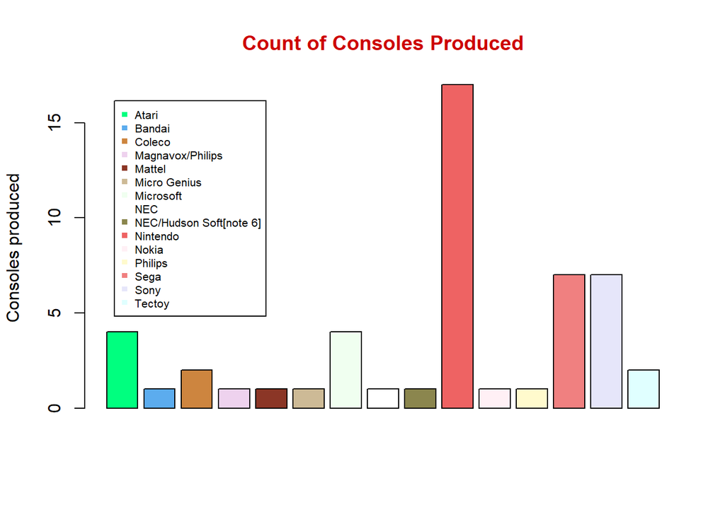

```r
type_table <- aggregate(type~company, data = console_data, FUN = length)
cols <- c("springgreen","steelblue2", "tan3","thistle2" ,"tomato4",
          "wheat3","honeydew","grey100" ,"khaki4","indianred2" ,
          "lavenderblush1","lemonchiffon1","lightcoral", "lavender","lightcyan1")

barplot(type_table$type,
        ylab = "Consoles produced",
        col = cols,
        main = "Count of Consoles Produced",
        col.main ="red3")
legend("topleft",legend = type_table$company,
       cex=0.65,col=cols,
       pch=15,
       inset = 0.05)
```

## Units distributed

- As of 2020 the various companies had distributed 1.8 billion consoles cumulatively
- There has been an upward trend since inception with most distribution happening in 2004 236 Million units distributed
- The spikes were noted during the launch of new console pieces or upgrade of the existing ones

```r
paste0(round(sum(console_data$unitsold)/1000,1)," Billion")
```

```
## [1] "1.8 Billion"
```

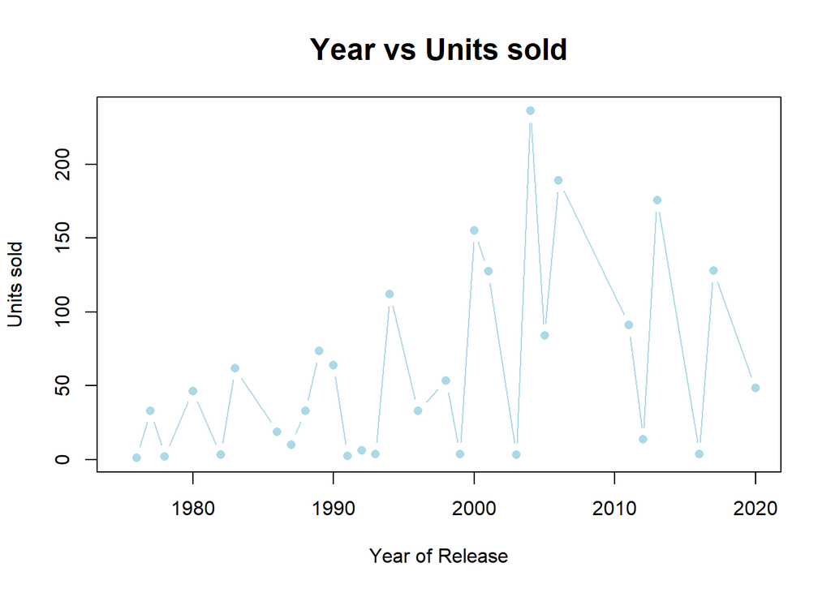

```r
year_prod <- aggregate(unitsold~releaseyr, data = console_data, FUN = sum)

plot(year_prod$releaseyr, year_prod$unitsold,
      type = 'b',
      main = "Year vs Units sold",
      col = 'lightblue',
      xlim = c(1975, 2020),
      xlab = "Year of Release",
      ylab = "Units sold",
      pch = 16,
      cex.main = 1.5)
```

## Category comparison

- Home consoles are the most popular the ones produced in large numbers, same applies for distribution as well,it’s preference is high since serves almost the entire family unit
- Handheld are meant to be portable, comes through second in terms of production, the numbers may even get lower with smart phone innovations that can come with captivating games

```r
company_pro <- aggregate(company~type, data = console_data, FUN = length)
company_pro
```

```
##                  type company
## 1           Dedicated       4
## 2            Handheld      12
## 3                Home      31
## 4 Home console add-on       3
## 5              Hybrid       1
```

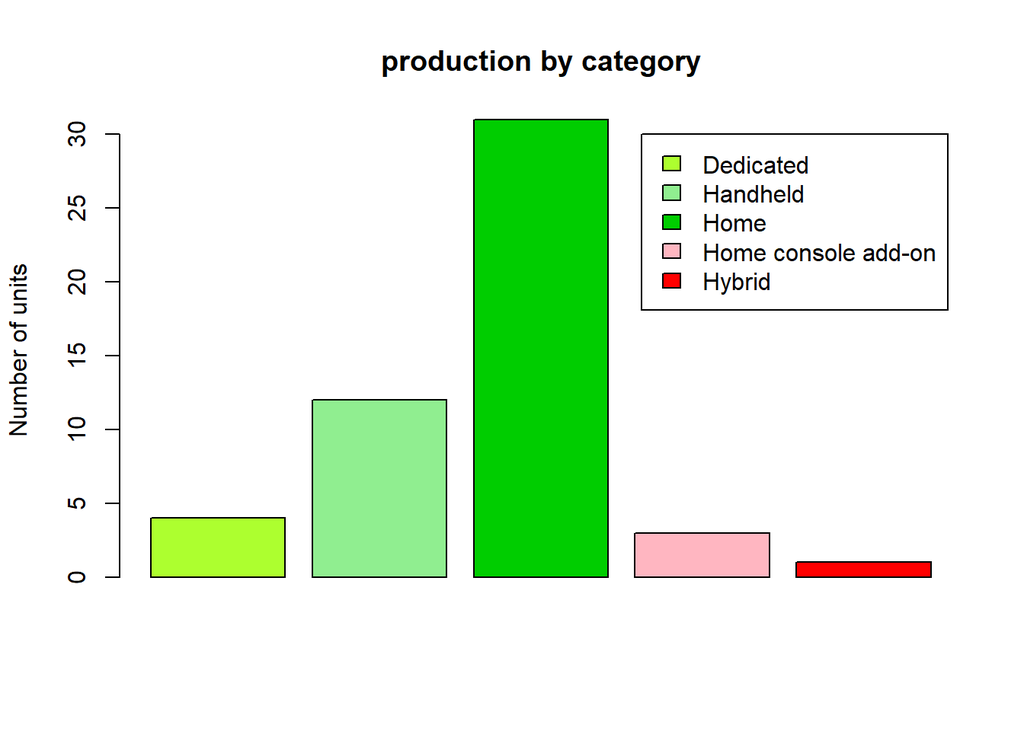

```r
# Home category is a common console, most are produced for home use,
#Followed through by handheld, these are portable
color =c('greenyellow', 'lightgreen','green3', 'lightpink','red')

barplot(company_pro$company,
        main = 'production by category',
        ylab = "Number of units",
        col = color,
        legend = company_pro$type)
```

## Company distribution comparison in Millions

- Nintendo have the highest number of consoles distributed, the same can be attributed to the fact that its started production in year 1977 as compared to the main competitors Sony and Microsoft who entered the field in 1994 and 2001 respectively
- With new innovations for Sony and Microsoft, PS5 and X-box series X respectively, the distribution and especially for Sony is expected to spike and reach the heights of Nintendo

```r
cols <- c("springgreen","steelblue2", "tan3","thistle2" ,"tomato4",
          "wheat3","honeydew","grey100" ,"khaki4","indianred2" ,
          "lavenderblush1","lemonchiffon1","lightcoral", "lavender","lightcyan1")

most_distributed <- aggregate(unitsold~company, data = console_data, FUN = sum)
most_distributed <- most_distributed[order(most_distributed$unitsold,
                                           decreasing = TRUE),]
most_distributed
```

```
##                    company unitsold
## 10                Nintendo   883.11
## 14                    Sony   589.09
## 7                Microsoft   185.00
## 13                    Sega    78.40
## 1                    Atari    33.00
## 15                  Tectoy    11.00
## 9  NEC/Hudson Soft[note 6]    10.00
## 6             Micro Genius     6.00
## 2                   Bandai     3.50
## 3                   Coleco     3.00
## 5                   Mattel     3.00
## 11                   Nokia     3.00
## 4         Magnavox/Philips     2.00
## 8                      NEC     1.92
## 12                 Philips     1.00
```

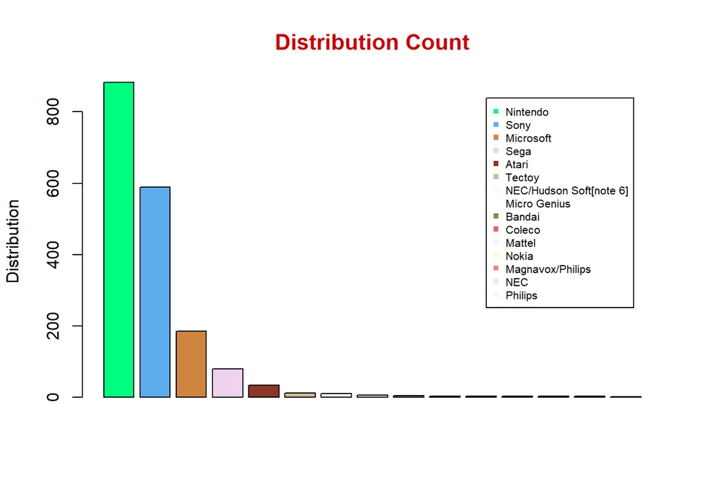

```r
barplot(most_distributed$unitsold,
        col = cols,
        main = "Distribution Count",
        cex.main = 1.3,
        col.main = 'red3',
        ylab = "Distribution")
legend("topright",legend = most_distributed$company,
       cex=0.65,col=cols,
       pch=15,
       inset = 0.05)
```